# Submission 2 - Intermediate

**Instructions**

- Fill out the 'Basic Information' and 'Simple Hypotheses - Findings / Insights' sections (replace the TODOs with your information)
  - If your visualization is interactive, create a short video that shows the interactivity (max. 3 min).
- Export the Jupyter notebook as a HTML file and save it in this repository.
  - Go to 'File' -> 'Save and Export Notebook As..' -> 'HTML'.
  - Save it locally in your project folder. You can leave the name as it is.
  - If you have a video, then add it to the project folder.
  - Push your local changes to the GitHub repository.
- Upload the generated HTML for the Moodle submission.
  - If you have a video, then upload that for the Moodle submission, too.

## Basic Information

**Team Name:** cyan crabs

**Team Members:**

- Fahmi Chammas fahmichammas@gmail.com 01523267
- Ping Chih Tsai pingchihtsai@outlook.com 12236246
- Suzana Božanić suzana.bozanic@gmail.com 12025729

**Dataset Description:**  
(max. 75 words)

This dataset (https://data.lacity.org/Public-Safety/Crime-Data-from-2020-to-Present/2nrs-mtv8) reflects incidents of crime in the City of Los Angeles from 2020 to present. Last update before download was on 8 November 2023. Additional income and population data were combined using geospatial data, because there is no official data on income per division. Some data on population exist on LAPD website, which are overestimated similarly like ours. We suspect that the data were acquired using similar methods.

Size of the Dataset: Rows:834K, Columns:28

## Simple Hypotheses - Findings / Insights

**Instructions:**

- Add your visualizations (**max. 4**) here
  - The visualizations should show the findings / insights
- Add the descriptions for all your findings / insights (**max. 150 words**)
  - The description should also relate to the visualizations above.

### Visualizations

```python
import geopandas as gpd
import numpy as np
import pandas as pd
import matplotlib.pylab as plt
import seaborn as sns

plt.style.use("ggplot")
pd.set_option("display.max_columns", 100)
```

```python
# url: https://data.lacity.org/Public-Safety/Crime-Data-from-2020-to-Present/2nrs-mtv8
# file is to large to be uploaded to data folder
# url = 'crime.csv'
# data = pd.read_csv(url)
```

```python
file_path = 'Crime_Data_from_2020_to_Present_20231112.csv'
data = pd.read_csv(file_path)
```

## 1. Is Hollywood the safest area in LA?

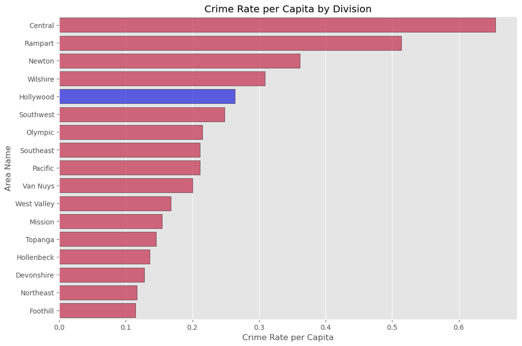

```python
file_path_population = 'combined_stats.csv'
population_df = pd.read_csv(file_path_population)

area_counts = data["AREA NAME"].value_counts()
colors = ['blue' if area == 'Hollywood' else 'crimson' for area, count in area_counts.items()]

# Counting crimes by division
crime_count_by_division = data.groupby('AREA NAME').size().reset_index(name='Crime Count')

# Merge the crime count data with population data
merged_data = pd.merge(crime_count_by_division, population_df, on='AREA NAME')

# Calculate the Crime Rate per Capita
merged_data['Crime Rate per Capita'] = merged_data['Crime Count'] / merged_data['Population']

# Sorting data for better visualization
sorted_data = merged_data.sort_values(by='Crime Rate per Capita', ascending=False)

# Setting colors: blue for Hollywood, crimson for others
sorted_data['color'] = sorted_data['AREA NAME'].apply(lambda x: 'blue' if x.strip().upper() == 'HOLLYWOOD' else 'crimson')

plt.figure(figsize=(12, 8))
sns.barplot(x='Crime Rate per Capita', y='AREA NAME', data=sorted_data, palette=colors, edgecolor='black', alpha=0.7)
plt.ylabel('Area Name')
plt.xlabel('Crime Rate per Capita')
plt.title('Crime Rate per Capita by Division')
plt.show()
```

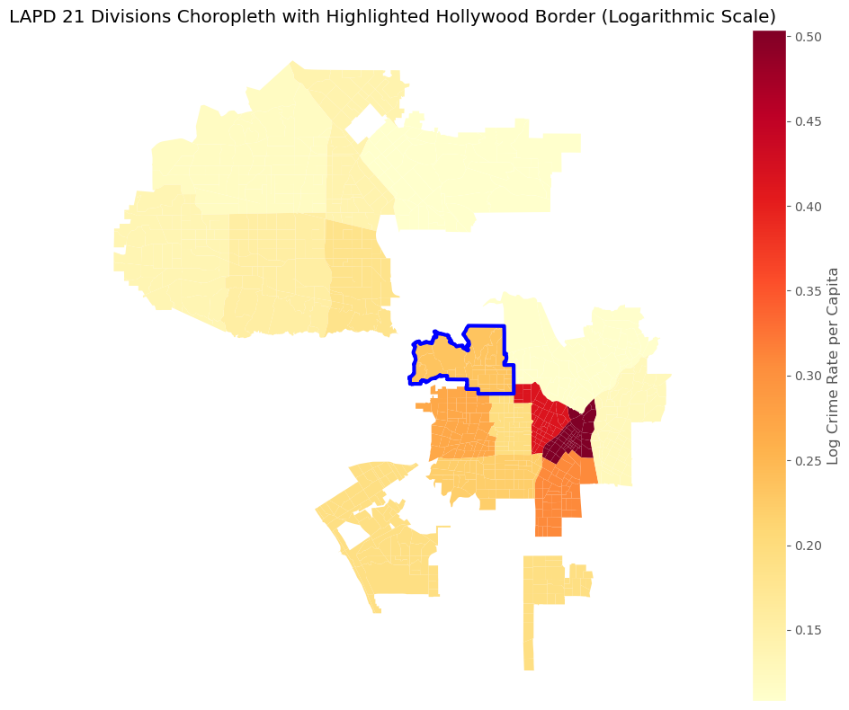

```python
import geopandas as gpd
import matplotlib.pyplot as plt

# Load shapefile
shapefile_path = "LAPD_Reporting_District.shp"
gdf = gpd.read_file(shapefile_path)

# Ensure case matching between gdf and merged_data for AREA NAME
gdf['APREC'] = gdf['APREC'].str.upper()
merged_data['AREA NAME'] = merged_data['AREA NAME'].str.upper()

# Merge geographical data with crime data
merged_gdf = gdf.merge(merged_data, left_on='APREC', right_on='AREA NAME', how='left')

# Calculate logarithm of Crime Rate per Capita
merged_gdf['Log Crime Rate'] = np.log1p(merged_gdf['Crime Rate per Capita'])

# Plotting the choropleth map
fig, ax_choropleth = plt.subplots(1, 1, figsize=(12, 8))
merged_gdf.plot(column='Log Crime Rate', cmap='YlOrRd', linewidth=0.8, ax=ax_choropleth, edgecolor='none', legend=True, legend_kwds={'label': "Log Crime Rate per Capita"})

# Extract Hollywood area and dissolve internal boundaries
hollywood_gdf = merged_gdf[merged_gdf['AREA NAME'] == 'HOLLYWOOD'].dissolve()

# Highlight Hollywood area with outer border only
hollywood_gdf.boundary.plot(ax=ax_choropleth, edgecolor='blue', linewidth=3)

# Customize the map
ax_choropleth.set_title('LAPD 21 Divisions Choropleth with Highlighted Hollywood Border (Logarithmic Scale)')
ax_choropleth.set_axis_off()
plt.tight_layout()
plt.show()
```

## 2. Are females the most common victims of crime in Los Angeles?

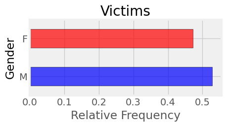

```python
plt.figure(figsize=(5, 2))
# Removing irrelevant gender values for our hypothesis
data = data.query('`Vict Sex` != "X" and `Vict Sex` != "H" and `Vict Sex` != "-"')
plt.style.use('fivethirtyeight')

# Calculate relative frequencies
rel_freq = data['Vict Sex'].value_counts(normalize=True)

# Defining the color scheme
colors = ['blue' if gender == 'M' else 'red' for gender in rel_freq.index]

ax = rel_freq.plot(kind="barh", title= "Victims", edgecolor='black', color = colors, alpha=0.7)
ax.set_ylabel('Gender', color = "black")
ax.set_xlabel('Relative Frequency')
plt.show()
```

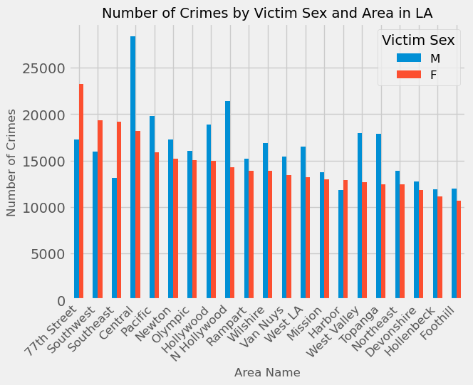

```python
# Counting crimes by victim sex and area
crime_by_sex_and_area = pd.crosstab(data['AREA NAME'], data['Vict Sex'])

# Selecting only male and female victim counts
crime_by_sex_and_area_mf = crime_by_sex_and_area[['M', 'F']]

# Sorting by the number of female victims
crime_by_sex_and_area_mf_sorted = crime_by_sex_and_area_mf.sort_values(by='F', ascending=False)

# Creating a bar plot for visualization
plt.figure(figsize=(3, 8))
crime_by_sex_and_area_mf_sorted.plot(kind='bar', stacked=False)
plt.title('Number of Crimes by Victim Sex and Area in LA', fontsize=14)
plt.xlabel('Area Name', fontsize=12)
plt.ylabel('Number of Crimes', fontsize=12)
plt.xticks(rotation=45, ha='right', fontsize=12)
plt.legend(title='Victim Sex', fontsize=12)
plt.show()
```

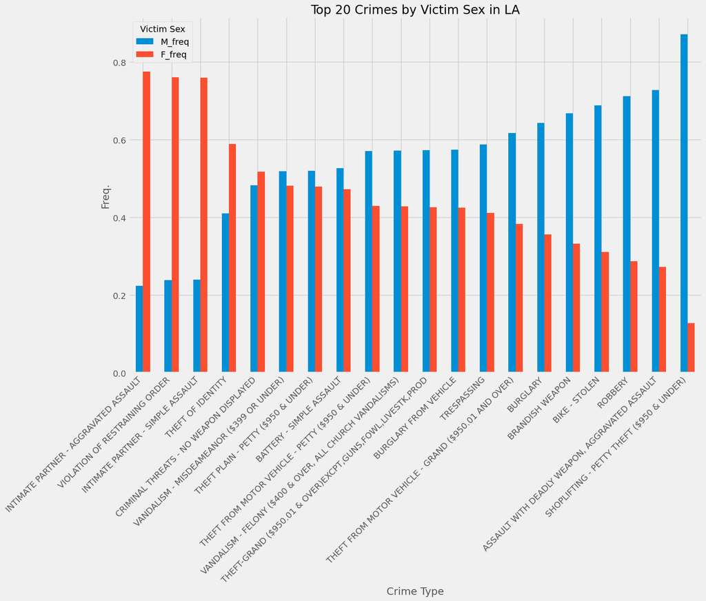

```python
import pandas as pd
import matplotlib.pyplot as plt

# Reload the dataset
file_path = 'Crime_Data_from_2020_to_Present_20231112.csv'
data_cleaned = pd.read_csv(file_path)

# Cleaning the dataset
data_cleaned['Date Rptd'] = pd.to_datetime(data_cleaned['Date Rptd'])
data_cleaned['DATE OCC'] = pd.to_datetime(data_cleaned['DATE OCC'])
data_cleaned['Mocodes'].fillna('Unknown', inplace=True)
data_cleaned['Vict Sex'].fillna('U', inplace=True)
data_cleaned['Vict Descent'].fillna('U', inplace=True)
data_cleaned['Premis Desc'].fillna('Unknown', inplace=True)
data_cleaned['Weapon Used Cd'].fillna(0, inplace=True)
data_cleaned['Weapon Desc'].fillna('None', inplace=True)

# Counting crimes by victim sex and type
crime_by_sex_and_type = pd.crosstab(data_cleaned['Crm Cd Desc'], data_cleaned['Vict Sex'])

# Selecting only male and female victim counts
crime_by_sex_and_type_mf = crime_by_sex_and_type[['M', 'F']].copy()

# Define the number of top crime types to display
top_n = 20

# Summing the male and female counts to get total counts
crime_by_sex_and_type_mf['Total'] = crime_by_sex_and_type_mf['M'] + crime_by_sex_and_type_mf['F']

# Select the top N crime types based on total count
top_crime_types = crime_by_sex_and_type_mf.nlargest(top_n, 'Total')

# Calculate relative frequencies of male and female victims within these top crimes
top_crime_types['M_freq'] = top_crime_types['M'] / top_crime_types['Total']
top_crime_types['F_freq'] = top_crime_types['F'] / top_crime_types['Total']

# Sorting the top crimes by female victim frequency in descending order
top_crime_types_sorted = top_crime_types.sort_values('F_freq', ascending=False)

# Plotting the sorted top crimes by female victim frequency
plt.figure(figsize=(15, 10))
top_crime_types_sorted[['M_freq', 'F_freq']].plot(kind='bar', stacked=False, ax=plt.gca())
plt.title(f'Top {top_n} Crimes by Victim Sex in LA')
plt.xlabel('Crime Type')
plt.ylabel('Freq.')
plt.xticks(rotation=45, ha='right')
plt.legend(title='Victim Sex')
plt.show()
```

### Description

Understanding patterns and distributions in categorical data is always more informative with a frequency-based perspective. To assess Hollywood's safety compared to other LAPD Divisions we used population count to empower our bar chart with quantitative power of comparison while our choropleth map provided us with geographical context. Almost the same, but different! Both served us well to realize that Beverly Hills doesn’t belong to LAPD jurisdiction.